```r
library(tidyverse)
```

*2. Children Learning to Read*

**a) Read in and display (some of) the data frame.**

```r
my_url <- "http://ritsokiguess.site/STAD29/reading_again.csv"
reading <- read_csv(my_url)
reading
```

```
## # A tibble: 36 x 3
##    method  reading income
##    <chr>     <dbl>  <dbl>
##  1 method1      12   17.5
##  2 method2      45   70.8
##  3 method3      20   71.4
##  4 method4      12   35
##  5 method1      39  105.
##  6 method2      37   45.9
##  7 method3      42   55
##  8 method4      10   33
##  9 method1      36   64.7
## 10 method2      13   47.5
## # … with 26 more rows
```

**b) Make a suitable plot of the data. Add regression lines for each method (without the grey envelopes). Bear in mind that we are trying to predict reading score from everything else.**

Two quantitative and one categorical variable, so plot the categorical variable using colour:

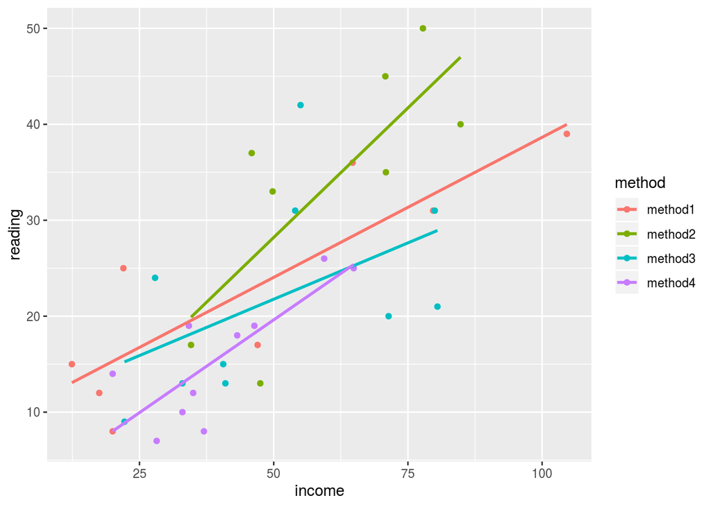

```r
ggplot(reading, aes(x = income, y = reading, colour = method)) +
  geom_point() + geom_smooth(method = "lm", se = F)
```

**c) Describe any effects of income and reading method on reading score that you see on the graph.**

**d) Run an analysis of variance on reading score as it depends on reading method. Display the results.**

```r
reading.1 <- aov(reading ~ method, data = reading)
summary(reading.1)
```

```
##             Df Sum Sq Mean Sq F value  Pr(>F)
## method       3   1455   485.0   4.503 0.00958 **
## Residuals   32   3447   107.7
## ---
## Signif. codes:  0 '***' 0.001 '**' 0.01 '*' 0.05 '.' 0.1 ' ' 1
```

The P-value on the F-test is less than 0.05, it is 0.00958. This means that reading scores depend on the reading method.

**e) Compare, using a suitable graph or numerical summary, the reading scores for the different reading methods. What is your main conclusion?**

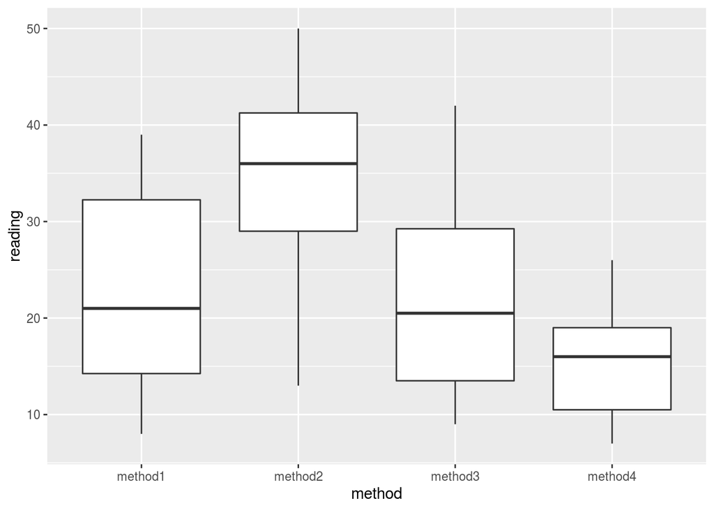

```r
ggplot(reading, aes(x = method, y = reading)) + geom_boxplot()
```

**f) Repeat the previous part, but this time comparing the family income by reading method (and not the reading scores). Again, comment briefly.**

```r
reading.2 <- aov(income ~ method, data = reading)
summary(reading.2)
```

```
##             Df Sum Sq Mean Sq F value Pr(>F)
## method       3   1897   632.4   1.254  0.307
## Residuals   32  16134   504.2
```

The P-value on the F-test is not less than 0.05, it is 0.307. This means that family income does not depend on reading method.

**g) Run a suitable analysis of covariance, and use drop1 with test=“F” to test the significance of the two explanatory variables. What do you conclude?**

```r
reading.3 <- lm(reading ~ income + method, data = reading)
drop1(reading.3, test = "F")
```

```
## Single term deletions
##
## Model:
## reading ~ income + method
##        Df Sum of Sq    RSS    AIC F value    Pr(>F)
## <none>              1768.5 150.20
## income  1   1678.35 3446.9 172.22 29.4194 6.367e-06 ***
## method  3    571.03 2339.6 154.27  3.3365   0.03194 *
## ---
## Signif. codes:  0 '***' 0.001 '**' 0.01 '*' 0.05 '.' 0.1 ' ' 1
```

Both the P-values are small, so there is evidence of an effect of income and method on reading scores.

**h) Compare the P-values for method from the analysis of covariance in the previous part and the analysis of variance you did earlier. Which one do you think is more trustworthy? Explain briefly.**

I think that the analysis of covariance is more trustworthy because income and method independently have an effect on reading score. But because income is significant in the previous part it is worth keeping in the ANCOVA as opposed to the ANOVA that was conducted previously.

*3. Technical Information About Diet*

**a) Read in and display (some of) the data. Make some kind of comment about whether you have what you were expecting.**

```r
my_url <- "http://ritsokiguess.site/STAD29/dietary.csv"
diet <- read_csv(my_url)
diet
```

```
## # A tibble: 33 x 4
##    group   useful difficulty importance
##    <chr>    <dbl>      <dbl>      <dbl>
##  1 website   19.6       5.15       9.5
##  2 website   15.4       5.75       9.10
##  3 website   22.3       4.35       3.30
##  4 website   24.3       7.55       5
##  5 website   22.5       8.5        6
##  6 website   20.5      10.2        5
##  7 website   14.1       5.95      18.8
##  8 website   13         6.30      16.5
##  9 website   14.1       5.45       8.90
## 10 website   16.7       3.75       6
## # … with 23 more rows
```

**b) Briefly explain why MANOVA is something we would consider to analyze these data.**

There are three response variables, useful, difficulty and importane, rather than just one. In order to do a test with more than one response variable, we need to use multivariate ANOVA rather than regular ANOVA.

**c) Make side-by-side boxplots of each of the three explanatory variables for each of the three groups. For full credit, do this in one ggplot.**

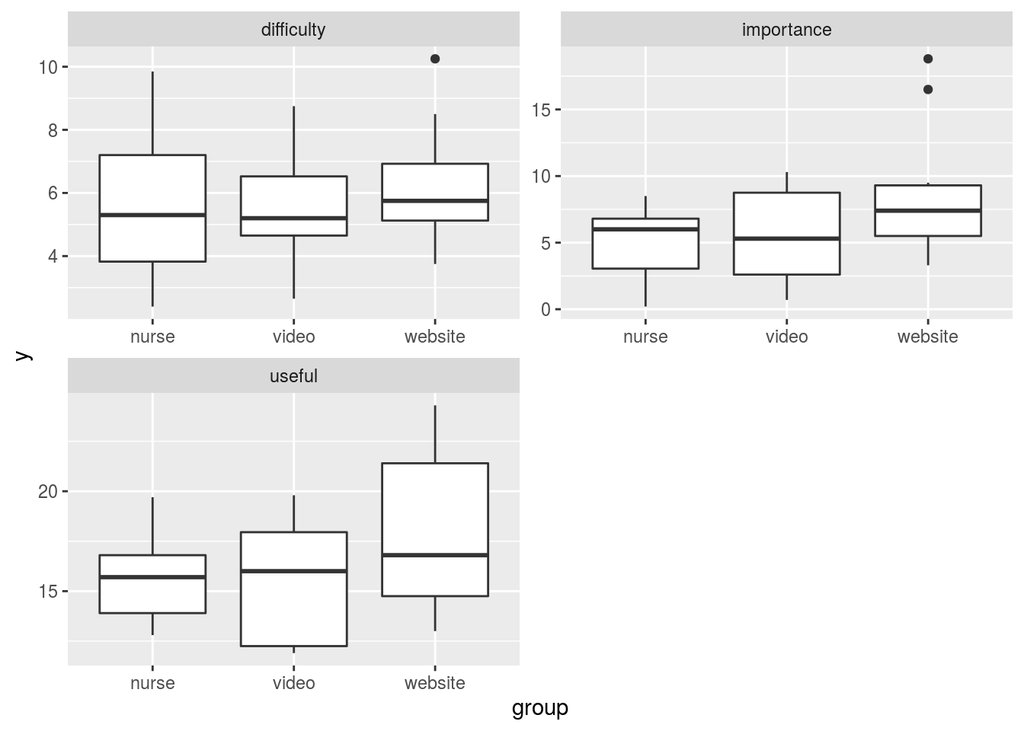

```r
diet %>%
  pivot_longer(useful:importance, names_to = "yname", values_to = "y") %>%
  ggplot(aes(x = group, y = y)) + geom_boxplot() + facet_wrap(~yname, scales = "free", ncol = 2)
```

**d) What does your plot suggest to you about the research objectives mentioned in the opening paragraph? Explain briefly.**

Website are generally highest in all three explanatory variables. Nurse and video are about the same for difficulty and useful. In importance the nurse group is higher than video. Some of the groups appear to be different on some of the variables, which would make a MANOVA come out significant.

**e) Run a suitable MANOVA on these data. Think about what your response variables are, what you have to do with them, what you explanatory variable(s) is/are, and how to run the analysis, There are several steps. What do you conclude in the end?**

```r
response <- with(diet, cbind(difficulty, importance, useful))
diet.1 <- manova(response ~ group, data = diet)
summary(diet.1)
```

```
##           Df  Pillai approx F num Df den Df  Pr(>F)
## group      2 0.47667   3.0248      6     58 0.01215 *
## Residuals 30
## ---
## Signif. codes:  0 '***' 0.001 '**' 0.01 '*' 0.05 '.' 0.1 ' ' 1
```

The null hypothesis (that each of the variables have the same mean for each of the groups) is rejected: that is, not all of the groups have the same mean on all of the variables.